# Notebook

Project Assignment A: An explanation of the central idea behind your final project, e.g. think about questions such as

What is the idea? **Investigating mental health data**

Which datasets do you need to explore the idea? **Surveys from different countries and also statistics from countries**

Why is it interesting? **Mental health is a developing issue and is very prevelent today**

A mock up of the visualization that you wish to build. (Anything is fine here. Pen and paper, MS Paint, Inkscape, D3, Midjourney (or any other LLM), anything is OK). **Map**

Make sure you answer the questions

What genre is it? (for Genres, see section 4.3 of the Segel and Heer paper) **Magazine style**

Why is that genre right for telling the story you want to communicate with the data **Because there are alot of underlying reasons for mental health problems that can best be explained with a text and visualization combo**

A walk-through of your preliminary data-analysis, addressing What is the total size of your data? (MB, number of rows, number of variables, etc) **4MB ish, 48 thousand rows ish, 44 variables**

What are other properties? (What is the date range? Is is it geo-data?, then a quick plot of locations, etc.) **1800-2017, Geo Data of most of the world (some countries missing like countries in Africa)**

Show the fundamental distributions of the data (similar to the work we did on SF crime data)

```python
from google.colab import drive
drive.mount('/content/drive')

# Imports
! pip install calplot
import pandas as pd
import numpy as np
import matplotlib.pyplot as plt
import requests
import json
import plotly.express as px
import pandas as pd
import calplot
import seaborn as sns
import geopandas as gpd



import warnings
warnings.filterwarnings("ignore")
```

```
     ━━━━━━━━━━━━━━━━━━━━━━━━━━━━━━━━━━━━━━━━ 132.3/132.3 kB 1.4 MB/s eta 0:00:00
  Preparing metadata (setup.py) ... done
```

# Load Data

We have different CSV files:

- Depression by Level of Education
- Number with depression by count
- Prevalence by mental and substance
- Prevalence of depression by age
- Prevalence of depression males
- Suicide Rates vs Prevalence of Depression

```python
dep_lvl_edu = pd.read_csv('/content/drive/MyDrive/vizzup-mental-health-depression-disorder-data/data/depression_by_level_of_educatio.csv')
num_dep_count = pd.read_csv('/content/drive/MyDrive/vizzup-mental-health-depression-disorder-data/data/number_with_depression_by_count.csv')
prev_mental_subst = pd.read_csv('/content/drive/MyDrive/vizzup-mental-health-depression-disorder-data/data/prevalence_by_mental_and_substa.csv')
prev_dep_age =  pd.read_csv('/content/drive/MyDrive/vizzup-mental-health-depression-disorder-data/data/prevalence_of_depression_by_age.csv')
prev_dep_males =  pd.read_csv('/content/drive/MyDrive/vizzup-mental-health-depression-disorder-data/data/prevalence_of_depression_males.csv')
suicide_vs_prev =  pd.read_csv('/content/drive/MyDrive/vizzup-mental-health-depression-disorder-data/data/suicide_rates_vs_prevalence_of.csv')
```

```python
prev_dep_males.head(200)
```

|  | entity | code | year | prevalence_in_males | prevalence_in_females | population |
| --- | --- | --- | --- | --- | --- | --- |
| 0 | Afghanistan | AFG | 1800 | NaN | NaN | 3280000.0 |
| 1 | Afghanistan | AFG | 1801 | NaN | NaN | 3280000.0 |
| 2 | Afghanistan | AFG | 1802 | NaN | NaN | 3280000.0 |
| 3 | Afghanistan | AFG | 1803 | NaN | NaN | 3280000.0 |
| 4 | Afghanistan | AFG | 1804 | NaN | NaN | 3280000.0 |
| ... | ... | ... | ... | ... | ... | ... |
| 195 | Afghanistan | AFG | 1995 | 3.522763 | 4.674739 | 18111000.0 |
| 196 | Afghanistan | AFG | 1996 | 3.524278 | 4.678305 | 18853000.0 |
| 197 | Afghanistan | AFG | 1997 | 3.529116 | 4.678696 | 19357000.0 |
| 198 | Afghanistan | AFG | 1998 | 3.534040 | 4.680175 | 19738000.0 |
| 199 | Afghanistan | AFG | 1999 | 3.537596 | 4.683704 | 20171000.0 |

200 rows × 6 columns

```python
suicide_vs_prev.head()
```

|  | entity | code | year | suicide_rate_deaths_per_100_000_individuals | depressive_disorder_rates_number_suffering_per_100_000 | population |
| --- | --- | --- | --- | --- | --- | --- |
| 0 | Afghanistan | AFG | 1800 | NaN | NaN | 3280000.0 |
| 1 | Afghanistan | AFG | 1801 | NaN | NaN | 3280000.0 |
| 2 | Afghanistan | AFG | 1802 | NaN | NaN | 3280000.0 |
| 3 | Afghanistan | AFG | 1803 | NaN | NaN | 3280000.0 |
| 4 | Afghanistan | AFG | 1804 | NaN | NaN | 3280000.0 |

```python
dep_lvl_edu.head(10)
```

|  | entity | code | year | all_levels_active | all_levels_employed | all_levels_total | below_upper_secondary_active | below_upper_secondary_employed | below_upper_secondary_total | tertiary_active | tertiary_employed | tertiary_total | upper_secondary_post_secondary_non_tertiary_active | upper_secondary_post_secondary_non_tertiary_employed | upper_secondary_post_secondary_non_tertiary_total |
| --- | --- | --- | --- | --- | --- | --- | --- | --- | --- | --- | --- | --- | --- | --- | --- |
| 0 | Austria | AUT | 2014 | 6.5 | 4.7 | 7.7 | 15.5 | 9.0 | 15.2 | 4.3 | 3.5 | 5.5 | 5.5 | 4.2 | 6.7 |
| 1 | Belgium | BEL | 2014 | 5.0 | 4.1 | 7.1 | 7.1 | 4.8 | 11.6 | 3.7 | 3.3 | 4.2 | 5.7 | 5.0 | 7.5 |
| 2 | Czech Republic | CZE | 2014 | 3.0 | 2.6 | 4.0 | 2.1 | 2.5 | 6.0 | 1.7 | 1.7 | 2.0 | 3.5 | 3.0 | 4.4 |
| 3 | Denmark | DNK | 2014 | 6.7 | 5.7 | 8.3 | 10.4 | 6.5 | 15.5 | 5.7 | 4.7 | 6.7 | 7.4 | 6.9 | 8.8 |
| 4 | Estonia | EST | 2014 | 3.8 | 3.8 | 5.1 | 4.7 | 4.7 | 6.4 | 3.6 | 3.6 | 4.3 | 3.7 | 3.8 | 5.2 |
| 5 | Finland | FIN | 2014 | 8.5 | 7.2 | 10.7 | 7.4 | 3.1 | 14.4 | 7.4 | 6.7 | 8.9 | 10.9 | 9.2 | 13.2 |
| 6 | France | FRA | 2014 | 5.2 | 4.7 | 6.3 | 7.7 | 7.1 | 9.4 | 4.2 | 4.0 | 4.9 | 4.9 | 4.3 | 5.7 |
| 7 | Germany | DEU | 2014 | 10.3 | 9.6 | 11.6 | 14.4 | 12.4 | 17.0 | 8.2 | 7.9 | 8.9 | 11.4 | 10.6 | 12.5 |
| 8 | Greece | GRC | 2014 | 2.8 | 2.2 | 3.6 | 4.2 | 2.9 | 5.4 | 2.0 | 1.6 | 2.4 | 2.9 | 2.7 | 3.4 |
| 9 | Hungary | HUN | 2014 | 2.8 | 2.2 | 4.7 | 6.5 | 6.2 | 10.3 | 2.0 | 1.6 | 2.8 | 2.6 | 2.1 | 4.2 |

# Example Plot: Worldwide prevalence of depression (2017)

```python
# Calculate the mean and median of depression prevalence for each year
mean_median_df = prev_mental_subst.groupby('year')['depression'].agg(['mean', 'median']).reset_index()

# Create a new DataFrame with 'total' as the entity value
prev_mental_subst_total = pd.DataFrame({
    'entity': ['total'] * len(mean_median_df),
    'year': mean_median_df['year'],
    'depression_prevalence_mean': mean_median_df['mean'],
    'depression_prevalence_median': mean_median_df['median']
})

prev_mental_subst_total
```

|  | entity | year | depression_prevalence_mean | depression_prevalence_median |
| --- | --- | --- | --- | --- |
| 0 | total | 1990 | 3.506288 | 3.534532 |
| 1 | total | 1991 | 3.510948 | 3.529751 |
| 2 | total | 1992 | 3.515033 | 3.537933 |
| 3 | total | 1993 | 3.518531 | 3.537948 |
| 4 | total | 1994 | 3.521437 | 3.530053 |
| 5 | total | 1995 | 3.523328 | 3.530343 |
| 6 | total | 1996 | 3.524659 | 3.527299 |
| 7 | total | 1997 | 3.525602 | 3.516238 |
| 8 | total | 1998 | 3.525968 | 3.525654 |
| 9 | total | 1999 | 3.525664 | 3.510416 |
| 10 | total | 2000 | 3.524262 | 3.514953 |
| 11 | total | 2001 | 3.522087 | 3.513619 |
| 12 | total | 2002 | 3.519421 | 3.516777 |
| 13 | total | 2003 | 3.516446 | 3.520455 |
| 14 | total | 2004 | 3.513080 | 3.504829 |
| 15 | total | 2005 | 3.509253 | 3.502285 |
| 16 | total | 2006 | 3.502707 | 3.484572 |
| 17 | total | 2007 | 3.492855 | 3.484148 |
| 18 | total | 2008 | 3.482217 | 3.475210 |
| 19 | total | 2009 | 3.472895 | 3.466375 |
| 20 | total | 2010 | 3.467328 | 3.455801 |
| 21 | total | 2011 | 3.464513 | 3.449547 |
| 22 | total | 2012 | 3.461950 | 3.441824 |
| 23 | total | 2013 | 3.459763 | 3.443459 |
| 24 | total | 2014 | 3.458056 | 3.447327 |
| 25 | total | 2015 | 3.456916 | 3.451298 |
| 26 | total | 2016 | 3.456299 | 3.457355 |
| 27 | total | 2017 | 3.456795 | 3.463055 |

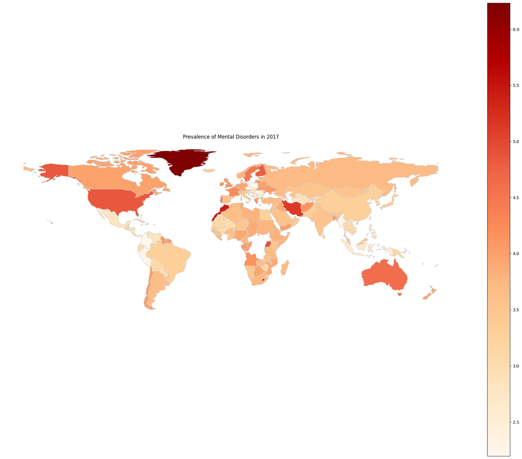

```python
# Filter the DataFrame for a specific year
year = 2017  # Replace with the year you want to visualize
prev_mental_subst_2017 = prev_mental_subst[prev_mental_subst['year'] == year]
prev_mental_subst_2017_dep = prev_mental_subst_2017[['entity','depression']]
prev_mental_subst_2017_dep['entity'] = prev_mental_subst_2017_dep['entity'].replace({'United States': 'United States of America'})


# Assuming you have a GeoDataFrame with world country geometries
world = gpd.read_file(gpd.datasets.get_path('naturalearth_lowres'))


# Merge the world GeoDataFrame with your DataFrame based on the 'entity' column
world_merged = world.merge(prev_mental_subst_2017_dep, how='left', left_on='name', right_on='entity')

# Plotting
fig, ax = plt.subplots(1, 1, figsize=(25, 20))
world_merged.plot(column='depression', cmap='OrRd', linewidth=0.8, ax=ax, edgecolor='0.8', legend=True)
ax.set_title(f'Prevalence of Mental Disorders in {year}')
plt.axis('off')
plt.show()
```

```python
# Find the country with the highest prevalence
highest_prevalence_country = prev_mental_subst_2017.loc[prev_mental_subst_2017['depression'].idxmax()]

# Find the country with the lowest prevalence
lowest_prevalence_country = prev_mental_subst_2017.loc[prev_mental_subst_2017['depression'].idxmin()]

# Print the results
print(f"Highest Prevalence: {highest_prevalence_country['entity']} : {highest_prevalence_country['depression']}")
print(f"Lowest Prevalence: {lowest_prevalence_country['entity']} : {lowest_prevalence_country['depression']}")
```

```
Highest Prevalence: Greenland : 6.23363488551
Lowest Prevalence: Colombia : 2.19615411587999
```

```python
# Find the 5 countries with the highest prevalence
highest_prevalence_countries = prev_mental_subst_2017.nlargest(5, 'depression')

# Find the 5 countries with the lowest prevalence
lowest_prevalence_countries = prev_mental_subst_2017.nsmallest(5, 'depression')

# Print the results
print("Countries with Highest Prevalence:")
for idx, row in highest_prevalence_countries.iterrows():
    print(f"{row['entity']} : {row['depression']}")

print("\nCountries with Lowest Prevalence:")
for idx, row in lowest_prevalence_countries.iterrows():
    print(f"{row['entity']} : {row['depression']}")
```

```
Countries with Highest Prevalence:
Greenland : 6.23363488551
Lesotho : 5.6366607037
Morocco : 5.41357318493
Iran : 5.11634462915
Uganda : 4.91802815738

Countries with Lowest Prevalence:
Colombia : 2.19615411587999
Albania : 2.20841419824
Poland : 2.25047189275
Peru : 2.2763210016
Myanmar : 2.30098157089
```

```python
from ipywidgets import interact, Dropdown


# Aggregate data by country and year
grouped_data = prev_mental_subst.groupby(['entity', 'year'])['depression'].mean().reset_index()

def update_plot(year):
    plt.figure(figsize=(15, 10))  # Adjust figure size as needed
    filtered_data = grouped_data[grouped_data['year'] == year]
    filtered_data = filtered_data.sort_values(by='depression', ascending=False)

    # Extract the country with the highest and lowest depression prevalence
    highest_country = filtered_data.iloc[0]['entity']
    highest_value = filtered_data.iloc[0]['depression']

    lowest_country = filtered_data.iloc[-1]['entity']
    lowest_value = filtered_data.iloc[-1]['depression']

    # Create a bar plot for all countries
    bars = plt.bar(filtered_data['entity'], filtered_data['depression'], color='skyblue')

    # Highlight bars for highest and lowest values
    for bar in bars:
        if bar.get_height() == highest_value:
            bar.set_color('skyblue')
        elif bar.get_height() == lowest_value:
            bar.set_color('skyblue')

    plt.xlabel('Country')
    plt.ylabel('Depression Prevalence')
    plt.title(f'Depression Prevalence in {year}')

    # Customize x-axis labels to display only highest and lowest countries
    plt.xticks(rotation=45, ha='right', fontsize=12)
    labels = plt.gca().get_xticklabels()
    for label in labels:
        if label.get_text() not in [highest_country, lowest_country]:
            label.set_visible(False)

    plt.tight_layout()  # Adjust layout to prevent clipping of labels
    plt.show()



# Get unique years
years = grouped_data['year'].unique()

# Create a dropdown widget
year_dropdown = Dropdown(options=years, description='Year:')

# Display the interactive plot
interact(update_plot, year=year_dropdown)
```

```
interactive(children=(Dropdown(description='Year:', options=(1990, 1991, 1992, 1993, 1994, 1995, 1996, 1997, 1…
```

```
update_plot
def update_plot(year)
```

```
/content/<ipython-input-10-38383a341699><no docstring>
```

```python
from ipywidgets import interact, Dropdown
import pandas as pd
import matplotlib.pyplot as plt
import nbformat
from nbconvert import HTMLExporter
import urllib.parse
from google.colab import drive

# Mount Google Drive
drive.mount('/content/drive')

# Assuming prev_mental_subst is your DataFrame
# grouped_data = prev_mental_subst.groupby(['entity', 'year'])['depression'].mean().reset_index()

def update_plot(year):
    plt.figure(figsize=(15, 10))
    filtered_data = grouped_data[grouped_data['year'] == year]
    filtered_data = filtered_data.sort_values(by='depression', ascending=False)

    highest_country = filtered_data.iloc[0]['entity']
    highest_value = filtered_data.iloc[0]['depression']

    lowest_country = filtered_data.iloc[-1]['entity']
    lowest_value = filtered_data.iloc[-1]['depression']

    bars = plt.bar(filtered_data['entity'], filtered_data['depression'], color='skyblue')

    for bar in bars:
        if bar.get_height() == highest_value:
            bar.set_color('orange')  # Highlight highest value
        elif bar.get_height() == lowest_value:
            bar.set_color('yellow')  # Highlight lowest value

    plt.xlabel('Country')
    plt.ylabel('Depression Prevalence')
    plt.title(f'Depression Prevalence in {year}')
    plt.xticks(rotation=45, ha='right', fontsize=12)

    labels = plt.gca().get_xticklabels()
    for label in labels:
        if label.get_text() not in [highest_country, lowest_country]:
            label.set_visible(False)

    plt.tight_layout()

    # Save the plot as a PNG file
    plt.savefig(f"/content/drive/MyDrive/depression_prevalence_{year}.png")

    plt.show()

# Get unique years
years = grouped_data['year'].unique()

# Create a dropdown widget
year_dropdown = Dropdown(options=years, description='Year:')

# Display the interactive plot
interact(update_plot, year=year_dropdown)

# Convert notebook to HTML
notebook_name = 'content/drive/MyDrive/SocialData_FinalProject.ipynb'  # Replace with your notebook name
html_exporter = HTMLExporter()
(body, resources) = html_exporter.from_notebook_node(nbformat.read(notebook_name, as_version=4))

# Save HTML file to Google Drive
with open(f"/content/drive/My rive/interactive_plot_{years[0]}_{years[-1]}.html", "w") as f:
    f.write(body)

print(f"Download the interactive plot as HTML: interactive_plot_{years[0]}_{years[-1]}.html")
```

```
interactive(children=(Dropdown(description='Year:', options=(1990, 1991, 1992, 1993, 1994, 1995, 1996, 1997, 1…
```

[output not shown]

# Example Plot: First time of depression in Greenland (2017)

```python
country = "Greenland"
year = 2017
prev_dep_age_greenland = prev_dep_age[prev_dep_age['entity'] == country]
prev_dep_age_greenland_2017 = prev_dep_age_greenland[prev_dep_age_greenland['year'] == year]

prev_dep_age_greenland_2017.head()
```

|  | entity | code | year | 20_24_years_old | 10_14_years_old | all_ages | 70_years_old | 30_34_years_old | 15_19_years_old | 25_29_years_old | 50_69_years_old | age_standardized | 15_49_years_old |
| --- | --- | --- | --- | --- | --- | --- | --- | --- | --- | --- | --- | --- | --- |
| 2267 | Greenland | GRL | 2017 | 10.381345 | 3.16435 | 6.577909 | 4.102642 | 8.790512 | 8.55065 | 9.441284 | 6.267714 | 6.233635 | 8.961353 |

```python
prev_dep_age_greenland_2017 = prev_dep_age_greenland_2017.reindex(columns=['entity','code','year','10_14_years_old','15_19_years_old','20_24_years_old','25_29_years_old','30_34_years_old','15_49_years_old','50_69_years_old','70_years_old'])
```

```python
prev_dep_age_greenland_2017
```

|  | entity | code | year | 10_14_years_old | 15_19_years_old | 20_24_years_old | 25_29_years_old | 30_34_years_old | 15_49_years_old | 50_69_years_old | 70_years_old |
| --- | --- | --- | --- | --- | --- | --- | --- | --- | --- | --- | --- |
| 2267 | Greenland | GRL | 2017 | 3.16435 | 8.55065 | 10.381345 | 9.441284 | 8.790512 | 8.961353 | 6.267714 | 4.102642 |

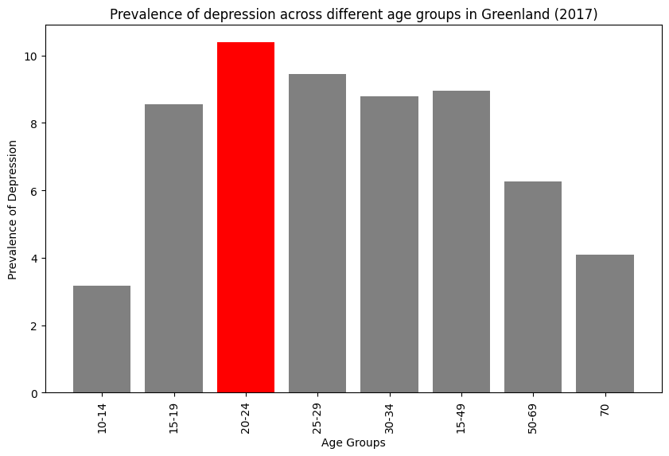

```python
# Define age groups
age_groups = ['10-14', '15-19', '20-24', '25-29', '30-34', '15-49', '50-69', '70']

values = prev_dep_age_greenland_2017.iloc[:, 3:].values.flatten()

# Get the index of the age group with the highest prevalence
max_index = np.argmax(values)

# Create a list of colors (gray for all age groups except the highest)
colors = ['gray'] * len(age_groups)
colors[max_index] = 'red'

# Plot the bar chart
plt.figure(figsize=(10, 6))
plt.bar(age_groups, values, color=colors)
plt.xlabel('Age Groups')
plt.ylabel('Prevalence of Depression')
plt.title('Prevalence of depression across different age groups in Greenland (2017)')
plt.xticks(rotation=90)
plt.show()
```

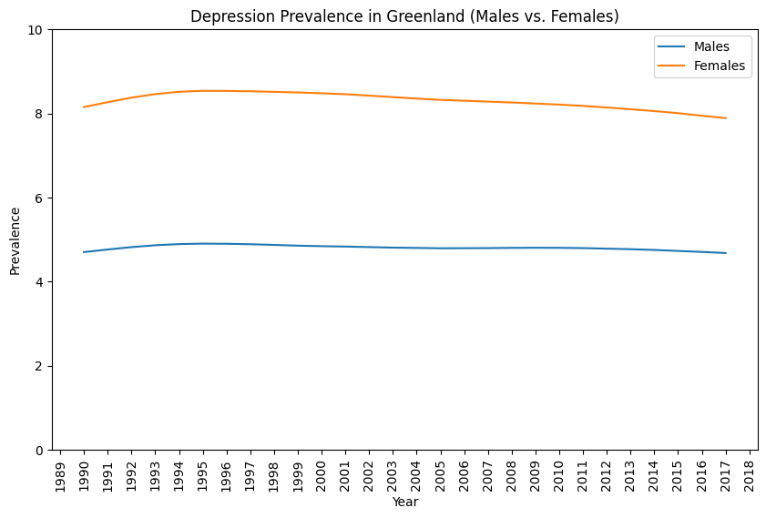

```python
country = 'Greenland'

# Filter data for the selected entity
prev_dep_males_greenland = prev_dep_males[prev_dep_males['entity'] == country]

# Create a time series plot
plt.figure(figsize=(10, 6))
plt.plot(prev_dep_males_greenland['year'], prev_dep_males_greenland['prevalence_in_males'], label='Males')
plt.plot(prev_dep_males_greenland['year'], prev_dep_males_greenland['prevalence_in_females'], label='Females')
plt.xlabel('Year')
plt.ylabel('Prevalence')
plt.title(f"Depression Prevalence in {country} (Males vs. Females)")
plt.legend()
plt.xticks(rotation=90)
plt.grid(False)
plt.ylim(0,10)
plt.show()
```